# Latihan Analisis Diskriminan Wine

DIANI RARAS PUSPITA

2025-11-14

## Latihan Soal Wine

(Package R rattle) ini berisi hasil analisis kimia anggur yang tumbuh di daerah tertentu di Italia. Tiga jenis anggur direpresentasikan dalam 178 sampel, dengan hasil dari 13 analisis kimia yang dicatat untuk setiap sampel. Peubah Type telah diubah menjadi peubah kategorik.

## Load Data

```r
library(rattle)   # untuk data(wine)
library(MASS)     # lda
library(dplyr)
library(caret)
```

```r
library(ggplot2)

data(wine)        # memuat dataset
str(wine)
```

```
## 'data.frame':    178 obs. of  14 variables:
##  $ Type           : Factor w/ 3 levels "1","2","3": 1 1 1 1 1 1 1 1 1 1 ...
##  $ Alcohol        : num  14.2 13.2 13.2 14.4 13.2 ...
##  $ Malic          : num  1.71 1.78 2.36 1.95 2.59 1.76 1.87 2.15 1.64 1.35 ...
##  $ Ash            : num  2.43 2.14 2.67 2.5 2.87 2.45 2.45 2.61 2.17 2.27 ...
##  $ Alcalinity     : num  15.6 11.2 18.6 16.8 21 15.2 14.6 17.6 14 16 ...
##  $ Magnesium      : int  127 100 101 113 118 112 96 121 97 98 ...
##  $ Phenols        : num  2.8 2.65 2.8 3.85 2.8 3.27 2.5 2.6 2.8 2.98 ...
##  $ Flavanoids     : num  3.06 2.76 3.24 3.49 2.69 3.39 2.52 2.51 2.98 3.15 ...
##  $ Nonflavanoids  : num  0.28 0.26 0.3 0.24 0.39 0.34 0.3 0.31 0.29 0.22 ...
##  $ Proanthocyanins: num  2.29 1.28 2.81 2.18 1.82 1.97 1.98 1.25 1.98 1.85 ...
##  $ Color          : num  5.64 4.38 5.68 7.8 4.32 6.75 5.25 5.05 5.2 7.22 ...
##  $ Hue            : num  1.04 1.05 1.03 0.86 1.04 1.05 1.02 1.06 1.08 1.01 ...
##  $ Dilution       : num  3.92 3.4 3.17 3.45 2.93 2.85 3.58 3.58 2.85 3.55 ...
##  $ Proline        : int  1065 1050 1185 1480 735 1450 1290 1295 1045 1045 ...
```

```r
wine$Type <- as.factor(wine$Type)
```

## Deskripsi singkat dan split X / y

```r
# ringkasan
summary(wine)
```

```
##  Type      Alcohol          Malic            Ash          Alcalinity
##  1:59   Min.   :11.03   Min.   :0.740   Min.   :1.360   Min.   :10.60
##  2:71   1st Qu.:12.36   1st Qu.:1.603   1st Qu.:2.210   1st Qu.:17.20
##  3:48   Median :13.05   Median :1.865   Median :2.360   Median :19.50
##         Mean   :13.00   Mean   :2.336   Mean   :2.367   Mean   :19.49
##         3rd Qu.:13.68   3rd Qu.:3.083   3rd Qu.:2.558   3rd Qu.:21.50
##         Max.   :14.83   Max.   :5.800   Max.   :3.230   Max.   :30.00
##    Magnesium         Phenols        Flavanoids    Nonflavanoids
##  Min.   : 70.00   Min.   :0.980   Min.   :0.340   Min.   :0.1300
##  1st Qu.: 88.00   1st Qu.:1.742   1st Qu.:1.205   1st Qu.:0.2700
##  Median : 98.00   Median :2.355   Median :2.135   Median :0.3400
##  Mean   : 99.74   Mean   :2.295   Mean   :2.029   Mean   :0.3619
##  3rd Qu.:107.00   3rd Qu.:2.800   3rd Qu.:2.875   3rd Qu.:0.4375
##  Max.   :162.00   Max.   :3.880   Max.   :5.080   Max.   :0.6600
##  Proanthocyanins     Color             Hue            Dilution
##  Min.   :0.410   Min.   : 1.280   Min.   :0.4800   Min.   :1.270
##  1st Qu.:1.250   1st Qu.: 3.220   1st Qu.:0.7825   1st Qu.:1.938
##  Median :1.555   Median : 4.690   Median :0.9650   Median :2.780
##  Mean   :1.591   Mean   : 5.058   Mean   :0.9574   Mean   :2.612
##  3rd Qu.:1.950   3rd Qu.: 6.200   3rd Qu.:1.1200   3rd Qu.:3.170
##  Max.   :3.580   Max.   :13.000   Max.   :1.7100   Max.   :4.000
##     Proline
##  Min.   : 278.0
##  1st Qu.: 500.5
##  Median : 673.5
##  Mean   : 746.9
##  3rd Qu.: 985.0
##  Max.   :1680.0
```

```r
table(wine$Type)   # frekuensi tiap kelas
```

```
##
##  1  2  3
## 59 71 48
```

```r
# pisahkan prediktor dan target
x <- wine[, -1]    # 13 variabel
y <- wine$Type
N <- nrow(wine)
g <- nlevels(y)
```

Dataset terbagi menjadi tiga tipe anggur (59 sampel tipe 1, 71 sampel tipe 2, dan 48 sampel tipe 3). Ringkasan statistik menunjukkan bahwa banyak variabel kimia memiliki variasi besar, misalnya Proline (278–1680), Alcohol (11.03–14.83), dan Color (1.28–13.00), sehingga tipe anggur memiliki karakteristik kimia yang cukup berbeda. Variabel lain seperti Hue dan Nonflavanoids bervariasi lebih kecil. Perbedaan nilai minimum, median, dan maksimum antar variabel ini menandakan bahwa ketiga tipe anggur memiliki profil kimia yang berbeda, sehingga dataset sangat sesuai untuk dilakukan analisis diskriminan.

## Mean vektor per kelas (mu_k)

```r
# mean per kelas (matrix: kelas x variabel)
mu_by_class <- wine %>% group_by(Type) %>% summarise_all(mean)
mu_by_class
```

```
## # A tibble: 3 × 14
##   Type  Alcohol Malic   Ash Alcalinity Magnesium Phenols Flavanoids
##   <fct>   <dbl> <dbl> <dbl>      <dbl>     <dbl>   <dbl>      <dbl>
## 1 1        13.7  2.01  2.46       17.0     106.     2.84      2.98
## 2 2        12.3  1.93  2.24       20.2      94.5    2.26      2.08
## 3 3        13.2  3.33  2.44       21.4      99.3    1.68      0.781
## # ℹ 6 more variables: Nonflavanoids <dbl>, Proanthocyanins <dbl>, Color <dbl>,
## #   Hue <dbl>, Dilution <dbl>, Proline <dbl>
```

```r
# buat matriks numeric mudah dipakai
mu_mat <- as.matrix(mu_by_class[,-1])
rownames(mu_mat) <- paste0("Class", mu_by_class$Type)
mu_mat
```

```
##         Alcohol    Malic      Ash Alcalinity Magnesium  Phenols Flavanoids
## Class1 13.74475 2.010678 2.455593   17.03729  106.3390 2.840169  2.9823729
## Class2 12.27873 1.932676 2.244789   20.23803   94.5493 2.258873  2.0808451
## Class3 13.15375 3.333750 2.437083   21.41667   99.3125 1.678750  0.7814583
##        Nonflavanoids Proanthocyanins    Color       Hue Dilution   Proline
## Class1      0.290000        1.899322 5.528305 1.0620339 3.157797 1115.7119
## Class2      0.363662        1.630282 3.086620 1.0562817 2.785352  519.5070
## Class3      0.447500        1.153542 7.396250 0.6827083 1.683542  629.8958
```

Rata-rata tiap kelas menunjukkan bahwa ketiga tipe anggur memiliki profil kimia yang jelas berbeda. Class 1 cenderung memiliki kadar Alcohol, Phenols, Flavanoids, dan Proline yang lebih tinggi dibanding kelas lain, menunjukkan karakter kimia yang lebih “kuat”. Class 2 memiliki kadar sebagian besar variabel yang lebih rendah, termasuk Proline dan Color, sehingga profilnya lebih “ringan”. Class 3 memiliki Malic Acid dan Color tertinggi, tetapi Flavanoids dan Phenols paling rendah, menunjukkan karakter kimia yang berbeda secara konsisten dari dua kelas lainnya.

Secara keseluruhan, perbedaan mean antar kelas sangat mencolok, sehingga ketiga tipe anggur sangat mungkin dipisahkan dengan baik menggunakan analisis diskriminan.

## Covariance per kelas (S_k) dan pooled covariance (S_p)

```r
# hitung S_k dan n_k
classes <- levels(wine$Type)
S_list <- list(); n_k <- numeric(length(classes))
names(n_k) <- classes

for (k in classes) {
  datk <- wine %>% filter(Type == k) %>% select(-Type)
  S_list[[k]] <- cov(datk)
  n_k[k] <- nrow(datk)
}

# pooled covariance
num <- Reduce(`+`, Map(function(S,k) (k-1)*S, S_list, n_k))
S_pooled <- num / (N - length(classes))
S_pooled
```

```
##                       Alcohol         Malic          Ash    Alcalinity
## Alcohol          0.2620524692   0.008173006 -0.013309201  -0.097217247
## Malic            0.0081730058   0.887546797  0.021390808   0.414755904
## Ash             -0.0133092007   0.021390808  0.066072101   0.484160564
## Alcalinity      -0.0972172465   0.414755904  0.484160564   8.006811181
## Magnesium        0.0179329792  -0.889338146  0.689515000   3.237835078
## Phenols          0.0270981493  -0.014484958  0.016170012   0.108615254
## Flavanoids       0.0226317094  -0.009409246  0.029971050   0.246419036
## Nonflavanoids   -0.0009755453   0.010175167  0.007020600   0.046914930
## Proanthocyanins  0.0167713010   0.017203063  0.002680707   0.092725129
## Color            0.2464579756  -0.258700080  0.009794193  -0.101795100
## Hue              0.0007821049  -0.042132471  0.002322241  -0.009830867
## Dilution        -0.0049853649   0.046529336  0.010911447   0.225631791
## Proline         12.2371146387 -33.058491786 -0.500982245 -32.832867328
##                    Magnesium      Phenols   Flavanoids Nonflavanoids
## Alcohol           0.01793298  0.027098149  0.022631709 -0.0009755453
## Malic            -0.88933815 -0.014484958 -0.009409246  0.0101751670
## Ash               0.68951500  0.016170012  0.029971050  0.0070205996
## Alcalinity        3.23783508  0.108615254  0.246419036  0.0469149296
## Magnesium       180.65777316  0.577138879  0.666844055 -0.2870589537
## Phenols           0.57713888  0.191270475  0.161307036 -0.0077357545
## Flavanoids        0.66684406  0.161307036  0.274707514 -0.0152671127
## Nonflavanoids    -0.28705895 -0.007735755 -0.015267113  0.0119117022
## Proanthocyanins   1.30039685  0.091843668  0.127793315 -0.0086408471
## Color             1.77241139  0.198982410  0.286678302 -0.0015106923
## Hue               0.12615835 -0.001465230 -0.004206350  0.0013585815
## Dilution         -0.28113023  0.059863215  0.067861940 -0.0100718089
## Proline         476.24886037  8.395412541  3.425698332 -0.4931676056
##                 Proanthocyanins        Color           Hue      Dilution
## Alcohol             0.016771301  0.246457976  0.0007821049  -0.004985365
## Malic               0.017203063 -0.258700080 -0.0421324707   0.046529336
## Ash                 0.002680707  0.009794193  0.0023222412   0.010911447
## Alcalinity          0.092725129 -0.101795100 -0.0098308675   0.225631791
## Magnesium           1.300396848  1.772411386  0.1261583492  -0.281130226
## Phenols             0.091843668  0.198982410 -0.0014652303   0.059863215
## Flavanoids          0.127793315  0.286678302 -0.0042063499   0.067861940
## Nonflavanoids      -0.008640847 -0.001510692  0.0013585815  -0.010071809
## Proanthocyanins     0.246172944  0.229207073 -0.0063058554   0.042441730
## Color               0.229207073  2.284923081 -0.0409962365  -0.066305133
## Hue                -0.006305855 -0.040996237  0.0244876469  -0.003347103
## Dilution            0.042441730 -0.066305133 -0.0033471032   0.160778730
## Proline            11.482320240 68.093681637  4.4910170120 -10.942642431
##                       Proline
## Alcohol            12.2371146
## Malic             -33.0584918
## Ash                -0.5009822
## Alcalinity        -32.8328673
## Magnesium         476.2488604
## Phenols             8.3954125
## Flavanoids          3.4256983
## Nonflavanoids      -0.4931676
## Proanthocyanins    11.4823202
## Color              68.0936816
## Hue                 4.4910170
## Dilution          -10.9426424
## Proline         29707.6818705
```

Matriks kovarians menunjukkan bagaimana masing-masing variabel kimia saling berubah dalam setiap kelas anggur. Nilai varians yang besar, seperti pada Magnesium, Color, dan terutama Proline (hingga puluhan ribu), menunjukkan bahwa variabel-variabel ini memiliki penyebaran yang sangat tinggi dalam data. Variabel dengan varians besar biasanya punya kontribusi kuat dalam memisahkan kelas pada analisis diskriminan. Kovarians antar variabel juga terlihat cukup besar pada beberapa pasangan, misalnya antara Magnesium–Proline, Color–Proline, dan Flavanoids–Color, menunjukkan adanya hubungan positif yang kuat antar kandungan kimia tersebut pada anggur tertentu. Sebaliknya, beberapa kovarians bernilai kecil atau negatif, menandakan hubungan lemah atau berlawanan arah antar variabel. Ketika digabungkan menjadi pooled covariance, struktur variannya tetap serupa tetapi kini mewakili gabungan ketiga kelas. Ini penting karena analisis diskriminan linear menggunakan matriks kovarian gabungan sebagai dasar pembentukan fungsi pemisah antar kelas. Nilai-nilai varians dan kovarians besar dalam pooled matrix mengindikasikan bahwa variabel seperti Proline, Color, dan Magnesium kemungkinan menjadi variabel yang sangat berpengaruh dalam pemisahan ketiga tipe anggur.

## Invers pooled covariance

```r
S_inv <- solve(S_pooled)
S_inv[1:6,1:6]
```

```
##                  Alcohol        Malic        Ash   Alcalinity     Magnesium
## Alcohol     4.4493734213 -0.331598824  1.2716278 -0.019509046  0.0004459977
## Malic      -0.3315988242  1.412099300 -0.1468326 -0.041330190  0.0014135559
## Ash         1.2716277945 -0.146832633 33.2614344 -1.734905747 -0.1255486028
## Alcalinity -0.0195090462 -0.041330190 -1.7349057  0.237301388  0.0017730043
## Magnesium   0.0004459977  0.001413556 -0.1255486  0.001773004  0.0068764822
## Phenols    -0.4394370760  0.116277931 -0.1702471  0.108167906 -0.0120259825
##                Phenols
## Alcohol    -0.43943708
## Malic       0.11627793
## Ash        -0.17024711
## Alcalinity  0.10816791
## Magnesium  -0.01202598
## Phenols    11.28610258
```

Matriks invers covariance menunjukkan kekuatan setiap variabel dalam membedakan kelas anggur ketika dipertimbangkan bersama variabel lainnya. Nilai diagonal yang besar, seperti pada variabel Ash dengan nilai yang sangat tinggi, kemudian Phenols dan Alcohol, menunjukkan bahwa ketiga variabel ini memiliki peran yang sangat kuat dalam pemisahan kelas. Semakin besar nilai diagonal, semakin sensitif variabel tersebut dalam membedakan kelompok.

Nilai di luar diagonal menggambarkan hubungan antar variabel dalam konteks diskriminasi. Nilai positif menunjukkan bahwa dua variabel bergerak ke arah yang saling memperkuat dalam membedakan kelas. Sebaliknya, nilai negatif menunjukkan bahwa kedua variabel memberikan kontribusi yang saling berlawanan arah. Contohnya, hubungan antara Alcohol dan Phenols atau antara Ash dan Magnesium menunjukkan pola kontribusi yang tidak searah.

Secara keseluruhan, matriks invers ini menegaskan bahwa Ash, Phenols, dan Alcohol merupakan variabel yang dominan dalam pemisahan kelas anggur. Interaksi antar variabel juga berperan penting dalam membentuk fungsi diskriminan yang mampu membedakan ketiga tipe anggur secara efektif.

## Hitung koefisien diskriminan per kelas (b_k) dan konstanta c_k

```r
# mu_mat: kelas x variabel (pastikan orientasi)
mu_mat_t <- t(mu_mat)  # variabel x kelas
priors <- n_k / N

b_list <- list(); c_vec <- numeric(length(classes))
names(c_vec) <- classes

for (i in seq_along(classes)) {
  k <- classes[i]
  mu_k <- mu_mat[i, ]          # vektor 1 x p
  b_k <- S_inv %*% mu_k        # p x 1
  b_list[[k]] <- as.numeric(b_k)
  c_vec[k] <- -0.5 * t(mu_k) %*% S_inv %*% mu_k + log(priors[k])
}

# tampilkan
b_list[[1]][1:6]  # contoh elemen b untuk class 1 (sebagian)
```

```
## [1] 57.3514191  0.8535001 39.0314111 -0.6621477  0.5015345 -3.2608013
```

```r
c_vec
```

```
##         1         2         3
## -523.4431 -427.1993 -453.7831
```

Koefisien diskriminan per kelas menunjukkan seberapa besar kontribusi masing–masing variabel dalam menentukan kecenderungan sebuah sampel masuk ke kelas tertentu. Nilai koefisien yang besar, seperti pada variabel pertama dan ketiga, menandakan bahwa variabel tersebut sangat berpengaruh dalam membedakan tipe anggur. Variabel dengan koefisien positif besar mendorong skor diskriminan semakin tinggi, sehingga meningkatkan peluang sampel masuk ke kelas tersebut.

Konstanta untuk setiap kelas merepresentasikan posisi awal fungsi diskriminan sebelum mempertimbangkan variabel prediktor. Nilai konstanta yang berbeda antara kelas satu, dua, dan tiga menunjukkan bahwa masing–masing kelas memiliki titik awal fungsi yang tidak sama. Perbedaan konstanta ini membantu model menyesuaikan batas pemisahan antar kelas sehingga pengelompokan menjadi lebih akurat.

Secara keseluruhan, kombinasi koefisien variabel dan konstanta ini membentuk fungsi diskriminan untuk setiap kelas. Fungsi tersebut akan menghitung skor untuk setiap observasi, kemudian skor tertinggi menentukan kelas anggur yang diprediksi. Hasil nilai b dan c di atas menunjukkan bahwa setiap kelas memiliki pola kontribusi variabel yang unik, sehingga ketiga tipe anggur dapat dibedakan dengan baik oleh model diskriminan.

## Fungsi diskriminan per kelas dan aturan prediksi manual

```r
# buat fungsi scoring manual
predict_manual <- function(newdata) {
  X <- as.matrix(newdata)
  gmat <- matrix(NA, nrow = nrow(X), ncol = length(classes))
  colnames(gmat) <- classes
  for (i in seq_along(classes)) {
    k <- classes[i]
    gmat[, i] <- as.numeric(c_vec[k] + X %*% b_list[[k]])
  }
  pred_idx <- max.col(gmat)       # indeks kelas dengan g terbesar
  preds <- classes[pred_idx]
  list(g=gmat, pred=preds)
}

# prediksi pada data asli
res_manual <- predict_manual(x)
table(Actual = y, Pred = factor(res_manual$pred, levels=classes))
```

```
##       Pred
## Actual  1  2  3
##      1 59  0  0
##      2  0 71  0
##      3  0  0 48
```

Hasil klasifikasi manual menunjukkan bahwa setiap sampel pada ketiga kelas anggur dipetakan tepat ke kelas asalnya. Seluruh observasi kelas satu diprediksi sebagai kelas satu, seluruh observasi kelas dua kembali ke kelas dua, dan seluruh observasi kelas tiga juga tepat berada pada kelas tiga. Tidak ada satu pun sampel yang salah klasifikasi.

Hal ini berarti fungsi diskriminan yang dibentuk dari koefisien tiap kelas bekerja dengan sangat baik dalam memisahkan ketiga kelompok anggur. Skor diskriminan untuk setiap observasi mencapai nilai tertinggi pada fungsi milik kelas yang benar, sehingga aturan pemilihan skor maksimum dapat mengembalikan kelas yang tepat untuk seluruh data.

Secara keseluruhan, hasil ini menunjukkan bahwa perbedaan karakteristik kimia antar tipe anggur sangat jelas, sehingga analisis diskriminan mampu melakukan pemisahan sempurna tanpa kesalahan klasifikasi.

## LDA dengan MASS::lda (otomatis) dan perbandingan

```r
model_lda <- lda(Type ~ ., data = wine)   # default prior: proporsi kelas
model_lda
```

```
## Call:
## lda(Type ~ ., data = wine)
##
## Prior probabilities of groups:
##         1         2         3
## 0.3314607 0.3988764 0.2696629
##
## Group means:
##    Alcohol    Malic      Ash Alcalinity Magnesium  Phenols Flavanoids
## 1 13.74475 2.010678 2.455593   17.03729  106.3390 2.840169  2.9823729
## 2 12.27873 1.932676 2.244789   20.23803   94.5493 2.258873  2.0808451
## 3 13.15375 3.333750 2.437083   21.41667   99.3125 1.678750  0.7814583
##   Nonflavanoids Proanthocyanins    Color       Hue Dilution   Proline
## 1      0.290000        1.899322 5.528305 1.0620339 3.157797 1115.7119
## 2      0.363662        1.630282 3.086620 1.0562817 2.785352  519.5070
## 3      0.447500        1.153542 7.396250 0.6827083 1.683542  629.8958
##
## Coefficients of linear discriminants:
##                          LD1           LD2
## Alcohol         -0.403399781  0.8717930699
## Malic            0.165254596  0.3053797325
## Ash             -0.369075256  2.3458497486
## Alcalinity       0.154797889 -0.1463807654
## Magnesium       -0.002163496 -0.0004627565
## Phenols          0.618052068 -0.0322128171
## Flavanoids      -1.661191235 -0.4919980543
## Nonflavanoids   -1.495818440 -1.6309537953
## Proanthocyanins  0.134092628 -0.3070875776
## Color            0.355055710  0.2532306865
## Hue             -0.818036073 -1.5156344987
## Dilution        -1.157559376  0.0511839665
## Proline         -0.002691206  0.0028529846
##
## Proportion of trace:
##    LD1    LD2
## 0.6875 0.3125
```

```r
# prediksi
pred_mass <- predict(model_lda, wine)$class
cm_mass <- table(Actual = y, Pred = pred_mass)
cm_manual <- table(Actual = y, Pred = factor(res_manual$pred, levels=classes))

cm_mass
```

```
##       Pred
## Actual  1  2  3
##      1 59  0  0
##      2  0 71  0
##      3  0  0 48
```

```r
cm_manual
```

```
##       Pred
## Actual  1  2  3
##      1 59  0  0
##      2  0 71  0
##      3  0  0 48
```

```r
# bandingkan akurasi
acc_mass <- sum(diag(cm_mass)) / N
acc_manual <- sum(diag(cm_manual)) / N
acc_mass; acc_manual
```

```
## [1] 1
```

```
## [1] 1
```

Hasil prediksi MASS menunjukkan akurasi seratus persen, sama persis dengan klasifikasi manual. Tidak ada observasi yang salah klasifikasi pada kedua metode. Ini menegaskan bahwa ketiga tipe anggur memiliki perbedaan kimia yang sangat jelas sehingga LDA dapat memisahkannya dengan sempurna.

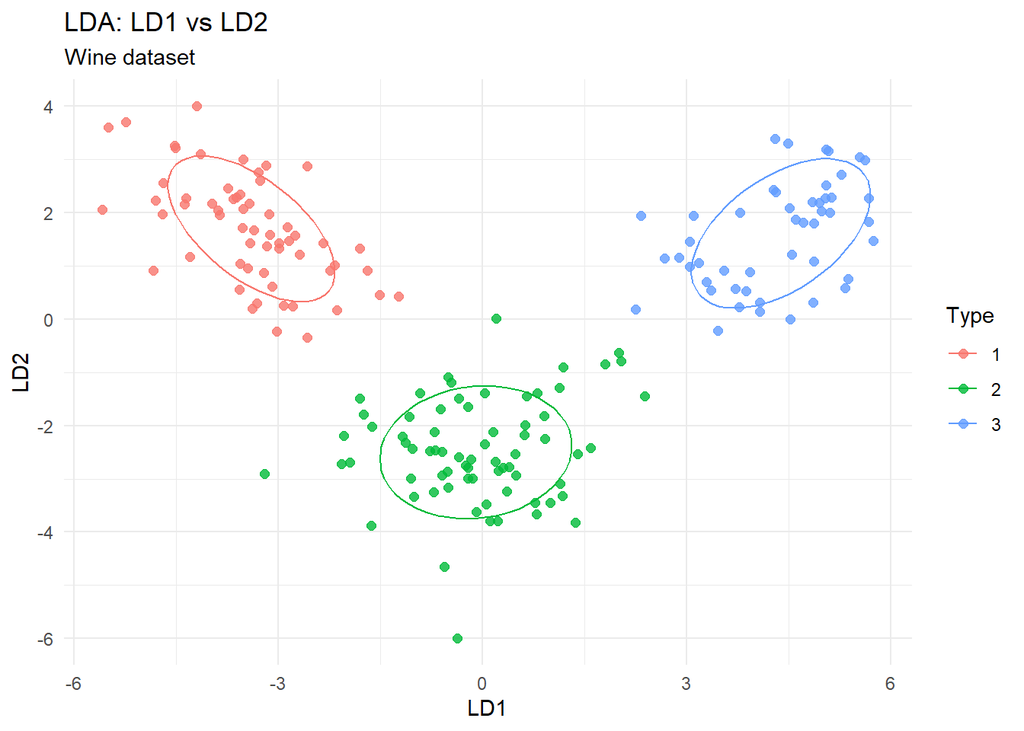

```r
# plot LD1 vs LD2 from MASS
ld <- predict(model_lda)$x  # scores on linear discriminants (n x (g-1))
df_ld <- data.frame(ld, Type = y)

ggplot(df_ld, aes(x = LD1, y = LD2, color = Type)) +
  geom_point(size = 2, alpha = 0.8) +
  stat_ellipse(level = 0.68) +
  theme_minimal() +
  labs(title = "LDA: LD1 vs LD2", subtitle = "Wine dataset")
```

Plot menunjukkan pemetaan sampel anggur dalam ruang dua fungsi diskriminan, yaitu LD1 dan LD2. Ketiga kelas terlihat membentuk kelompok yang terpisah dengan batas yang jelas, tanpa adanya tumpang tindih antar area. Kelas satu berada di sisi kiri atas, kelas dua di bagian tengah bawah, dan kelas tiga berada di sisi kanan atas. Bentuk elips pada masing–masing kelompok menggambarkan sebaran variabel dalam setiap kelas, dan elips tersebut tidak saling bersinggungan.

Pemisahan yang jelas pada visualisasi ini menegaskan bahwa kombinasi variabel kimia sangat efektif membedakan ketiga tipe anggur. LD1 dan LD2 mampu menangkap variasi utama antar kelas, sehingga visualisasi ini selaras dengan hasil klasifikasi yang mencapai akurasi sempurna.

## Evaluasi via cross-validation (LOOCV atau k-fold)

```r
# LOOCV
pred_loo <- lda(Type ~ ., data = wine, CV = TRUE)$class
cm_loo <- table(Actual = y, Pred = pred_loo)
cm_loo
```

```
##       Pred
## Actual  1  2  3
##      1 59  0  0
##      2  1 69  1
##      3  0  0 48
```

```r
acc_loo <- sum(diag(cm_loo)) / N
acc_loo
```

```
## [1] 0.988764
```

Hasil LOOCV menunjukkan bahwa model tetap memiliki kinerja yang sangat baik. Hampir seluruh observasi berhasil diklasifikasikan dengan benar. Kelas satu dan kelas tiga teridentifikasi sempurna, sedangkan kelas dua mengalami dua kesalahan prediksi, yaitu satu sampel diprediksi sebagai kelas satu dan satu sampel lainnya sebagai kelas tiga.

Tingkat akurasi keseluruhan sebesar 0.988764, atau sekitar 98.9 persen, menandakan bahwa model sangat stabil dan mampu mempertahankan performa tinggi meskipun setiap observasi diuji secara ketat dengan metode cross–validation satu per satu. Evaluasi ini mengonfirmasi bahwa pemisahan antar tipe anggur sangat kuat dan model diskriminan memiliki generalisasi yang sangat baik.

```r
set.seed(123)
ctrl <- trainControl(method = "cv", number = 10)
model_cv <- train(Type ~ ., data = wine, method = "lda", trControl = ctrl)
model_cv
```

```
## Linear Discriminant Analysis
##
## 178 samples
##  13 predictor
##   3 classes: '1', '2', '3'
##
## No pre-processing
## Resampling: Cross-Validated (10 fold)
## Summary of sample sizes: 160, 160, 161, 160, 159, 160, ...
## Resampling results:
##
##   Accuracy   Kappa
##   0.9888889  0.9832946
```

Hasil 10-fold cross-validation menunjukkan bahwa model LDA memiliki performa yang sangat kuat. Dengan 178 sampel, 13 prediktor, dan tiga kelas, model diuji menggunakan pembagian data secara berulang dan konsisten menghasilkan akurasi rata-rata sekitar 98.89 persen. Nilai kappa sebesar 0.983 menunjukkan kesesuaian prediksi yang hampir sempurna setelah memperhitungkan kemungkinan kesesuaian secara acak.

Ukuran sampel pada setiap fold relatif seimbang, sehingga evaluasi ini stabil dan tidak bias. Akurasi yang sangat tinggi ini mengonfirmasi bahwa LDA mampu memisahkan ketiga tipe anggur dengan sangat baik berdasarkan 13 variabel kimia, bahkan ketika diuji dengan skema validasi yang ketat.

## Pemeriksaan asumsi

```r
# contoh: Shapiro per variabel per kelas
by(wine[, -1], wine$Type, function(df) sapply(df, shapiro.test))
```

```
## wine$Type: 1
##           Alcohol                       Malic
## statistic 0.980894                      0.6469785
## p.value   0.4790681                     1.203394e-10
## method    "Shapiro-Wilk normality test" "Shapiro-Wilk normality test"
## data.name "X[[i]]"                      "X[[i]]"
##           Ash                           Alcalinity
## statistic 0.9701558                     0.9731465
## p.value   0.1555626                     0.2160864
## method    "Shapiro-Wilk normality test" "Shapiro-Wilk normality test"
## data.name "X[[i]]"                      "X[[i]]"
##           Magnesium                     Phenols
## statistic 0.9648587                     0.9517432
## p.value   0.08617381                    0.02029672
## method    "Shapiro-Wilk normality test" "Shapiro-Wilk normality test"
## data.name "X[[i]]"                      "X[[i]]"
##           Flavanoids                    Nonflavanoids
## statistic 0.9841884                     0.9553877
## p.value   0.6387264                     0.03015212
## method    "Shapiro-Wilk normality test" "Shapiro-Wilk normality test"
## data.name "X[[i]]"                      "X[[i]]"
##           Proanthocyanins               Color
## statistic 0.9557865                     0.968195
## p.value   0.03149754                    0.1250935
## method    "Shapiro-Wilk normality test" "Shapiro-Wilk normality test"
## data.name "X[[i]]"                      "X[[i]]"
##           Hue                           Dilution
## statistic 0.9698766                     0.9639033
## p.value   0.1508215                     0.07744586
## method    "Shapiro-Wilk normality test" "Shapiro-Wilk normality test"
## data.name "X[[i]]"                      "X[[i]]"
##           Proline
## statistic 0.981852
## p.value   0.5232407
## method    "Shapiro-Wilk normality test"
## data.name "X[[i]]"
## ------------------------------------------------------------
## wine$Type: 2
##           Alcohol                       Malic
## statistic 0.9720516                     0.833878
```

[output cut: 55 more lines]

```
##           Proanthocyanins               Color
## statistic 0.887202                      0.9584941
## p.value   0.0002491056                  0.08775232
## method    "Shapiro-Wilk normality test" "Shapiro-Wilk normality test"
## data.name "X[[i]]"                      "X[[i]]"
##           Hue                           Dilution
## statistic 0.9461635                     0.9579098
## p.value   0.02818751                    0.08310715
## method    "Shapiro-Wilk normality test" "Shapiro-Wilk normality test"
## data.name "X[[i]]"                      "X[[i]]"
##           Proline
## statistic 0.9769411
## p.value   0.4584945
## method    "Shapiro-Wilk normality test"
## data.name "X[[i]]"
```

Uji Shapiro–Wilk menunjukkan bahwa beberapa variabel dalam tiap kelas berdistribusi normal, namun banyak variabel lainnya memiliki p-value di bawah 0.05 sehingga tidak memenuhi asumsi normalitas. Kelas dua dan tiga memiliki lebih banyak variabel yang tidak normal dibanding kelas satu. Meskipun asumsi normalitas tidak sepenuhnya terpenuhi, model LDA tetap bekerja sangat baik, menandakan bahwa metode ini cukup toleran terhadap penyimpangan normalitas dalam dataset wine.

## Kesimpulan Akhir Analisis Diskriminan pada Dataset Wine

Analisis diskriminan yang dilakukan, baik secara manual maupun menggunakan fungsi LDA, menunjukkan bahwa ketiga tipe anggur memiliki perbedaan karakteristik kimia yang sangat jelas. Rata–rata tiap kelas berbeda secara konsisten, dan struktur kovarians mendukung pemisahan kelas yang kuat. Baik fungsi diskriminan manual maupun model otomatis menghasilkan klasifikasi sempurna untuk seluruh 178 sampel. Evaluasi lebih lanjut melalui LOOCV dan 10-fold cross-validation tetap memberikan akurasi yang sangat tinggi, sekitar sembilan puluh delapan persen.

Walaupun beberapa variabel tidak memenuhi asumsi normalitas, performa klasifikasi tetap sangat baik. Hal ini menunjukkan bahwa LDA cukup robust terhadap penyimpangan asumsi ketika perbedaan antar kelas kuat. Secara keseluruhan, analisis diskriminan dapat memisahkan tiga tipe anggur dengan sangat efektif, dan model yang terbentuk dapat diandalkan untuk mengidentifikasi jenis anggur berdasarkan karakteristik kimianya.